# Final Project Report Jianghui Li

About the Data: The data set approach student achievement in secondary education of two Portuguese schools – GP and MS. The data attributes include student grades, study time, parents’ information, and school-related features. The data was collected by using school surveys, and the dataset contains 649 rows and 33 columns. Data source: https://www.kaggle.com/larsen0966/student-performance-data-set

Questions: Does students’ performance in school closely related to other factors such as study time, attended school, parent’s education level, etc.? Are the correlations significant?

```r
#Loading Data
st<-read.csv("~/R/772/student-por.csv")
st<-na.omit(st)
str(st)
```

```
## 'data.frame':    649 obs. of  33 variables:
##  $ school    : Factor w/ 2 levels "GP","MS": 1 1 1 1 1 1 1 1 1 1 ...
##  $ sex       : Factor w/ 2 levels "F","M": 1 1 1 1 1 2 2 1 2 2 ...
##  $ age       : int  18 17 15 15 16 16 16 17 15 15 ...
##  $ address   : Factor w/ 2 levels "R","U": 2 2 2 2 2 2 2 2 2 2 ...
##  $ famsize   : Factor w/ 2 levels "GT3","LE3": 1 1 2 1 1 2 2 1 2 1 ...
##  $ Pstatus   : Factor w/ 2 levels "A","T": 1 2 2 2 2 2 2 1 1 2 ...
##  $ Medu      : int  4 1 1 4 3 4 2 4 3 3 ...
##  $ Fedu      : int  4 1 1 2 3 3 2 4 2 4 ...
##  $ Mjob      : Factor w/ 5 levels "at_home","health",..: 1 1 1 2 3 4 3 3 4 3 ...
##  $ Fjob      : Factor w/ 5 levels "at_home","health",..: 5 3 3 4 3 3 3 5 3 3 ...
##  $ reason    : Factor w/ 4 levels "course","home",..: 1 1 3 2 2 4 2 2 2 2 ...
##  $ guardian  : Factor w/ 3 levels "father","mother",..: 2 1 2 2 1 2 2 2 2 2 ...
##  $ traveltime: int  2 1 1 1 1 1 1 2 1 1 ...
##  $ studytime : int  2 2 2 3 2 2 2 2 2 2 ...
```

[output cut: 19 more lines]

```r
dim(st)
```

```
## [1] 649  33
```

Descriptive Statistics Since there are many variables in the dataset, observing their correlations with each other is essential. Then, find out some interesting or strong correlations to do a few detailed analyses.

Variables: school:‘GP’ - Gabriel Pereira or ‘MS’ - Mousinho da Silveira sex: Female and Male age: student’s age (numeric: from 15 to 22) Medu: mother’s education level (0 to 4) Fedu: father’s education level (0 to 4) studytime: weekly study time (numeric: 1 - <2 hours, 2 - 2 to 5 hours, 3 - 5 to 10 hours, or 4 - >10 hours) internet: no and yes freetime: free time after school (numeric: from 1 - very low to 5 - very high) famrel: quality of family relationships (numeric: from 1 - very bad to 5 - excellent) Dalc: workday alcohol consumption (numeric: from 1 - very low to 5 - very high) Walc: weekend alcohol consumption (numeric: from 1 - very low to 5 - very high) health: current health status (numeric: from 1 - very bad to 5 - very good) absences: number of school absences (numeric: from 0 to 93) G1, G2, G3: first period, second period, and final grade.

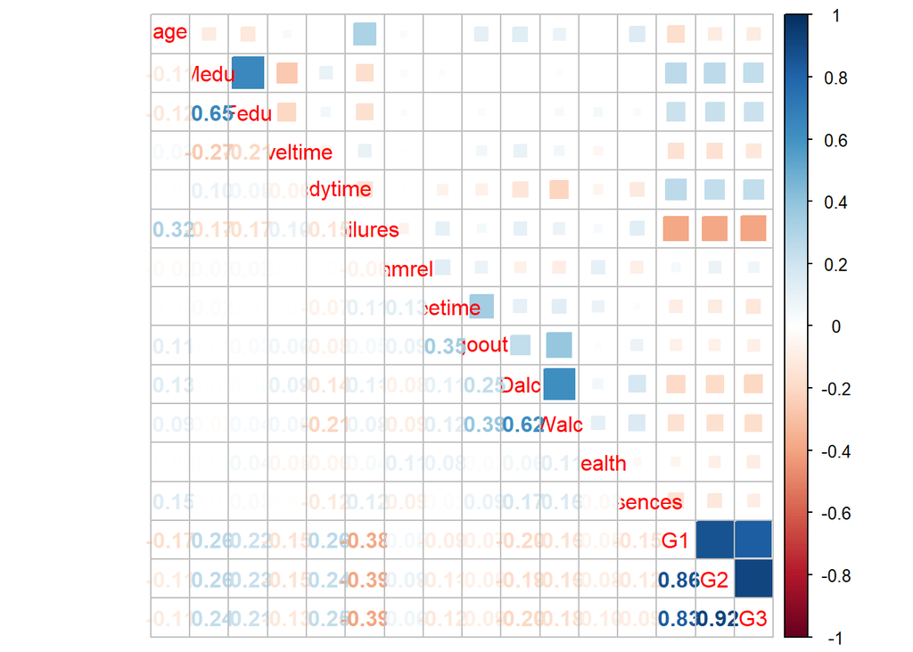

```r
#correlation plot 1
library(corrplot)
num.cols1 <- sapply(st, is.numeric)
cor.data1 <- cor(st[,num.cols1])
par(mfrow=c(1,1))
corrplot.mixed(cor.data1,upper = 'square')
```

After viewing the correlation plot, I am interested school, gender, parents’ education level, study time, and absences. Also, I want to add all three period grades together and using the average grade in a new column called GA.

```r
stData<-subset(st,select= c(school, sex, age, Medu, Fedu, studytime, absences, G1, G2, G3))
stData$GA<- (stData$G1+stData$G2+stData$G3)/3
stData<-subset(stData,select= -c(G1, G2, G3))
#School in Numbers
stData$schoolN[stData$school=="GP"]<-0
stData$schoolN[stData$school=="MS"]<-1
stData$schoolN<-as.numeric(stData$schoolN)
#Gender in Numbers
stData$sexN[stData$sex=="F"]<-0
stData$sexN[stData$sex=="M"]<-1
stData$sexN<-as.numeric(stData$sexN)
```

Here is the correlation plot using the variables that I am interested in.

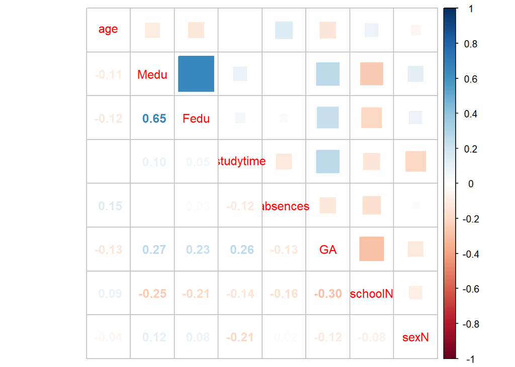

```r
num.cols <- sapply(stData, is.numeric)
cor.data <- cor(stData[,num.cols])
par(mfrow=c(1,1))
corrplot.mixed(cor.data,upper = 'square')
```

```r
#By looking at this plot, I found that parents’ education level, especially mothers’ education level and study time had positive correlation with students’ average grades. The students in two different school also perform differently. Gender, age, and absences had weak negative correlations with students’ average grade.
```

T Test I want to do a t-test to find out the mean difference between two schools’ students’ performance. Before I run the t-test, I want to show a boxplot, so I can see the distribution of students’ average grades.

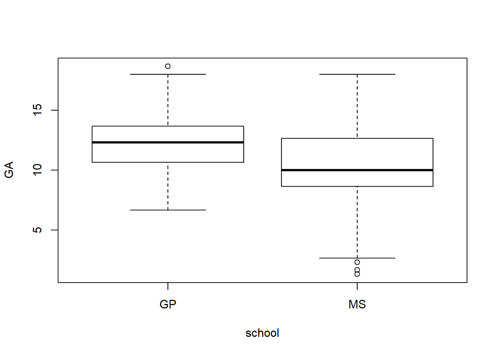

```r
boxplot(GA ~ school, data=stData)
```

```r
#The box plot shows that GP school has better median average score, and we need a t test to test out whether my observation is true.
```

```r
library(BayesFactor)
t.test(GA ~ school, data=stData)
```

```
##
##  Welch Two Sample t-test
##
## data:  GA by school
## t = 7.1675, df = 357.3, p-value = 4.41e-12
## alternative hypothesis: true difference in means is not equal to 0
## 95 percent confidence interval:
##  1.272240 2.234396
## sample estimates:
## mean in group GP mean in group MS
##         12.23562         10.48230
```

```r
#First of all, the p-value is smaller than the alpha value, so the result is significant. The 95 percent confidence interval is positive did not overlap with zero, which means, on average, students in GP tend to perform better than the students in MS.
#Then, let’s find out the odd ratio.
ttestBF(formula=GA ~ school, data=stData, posterior=FALSE)
```

```
## Bayes factor analysis
## --------------
## [1] Alt., r=0.707 : 331983584247 ±0%
##
## Against denominator:
##   Null, mu1-mu2 = 0
## ---
## Bayes factor type: BFindepSample, JZS
```

```r
#The odd ratio is big enough to be considered as strong evidence for the favored hypothesis. Then we will run ttestBF() with posterior = TRUE and iteration = 10000 times to observe to the HDI.
summary(ttestBF(formula=GA ~ school, data=stData, posterior=TRUE, iterations=10000))
```

```
##
## Iterations = 1:10000
## Thinning interval = 1
## Number of chains = 1
## Sample size per chain = 10000
##
## 1. Empirical mean and standard deviation for each variable,
##    plus standard error of the mean:
##
##                   Mean        SD  Naive SE Time-series SE
## mu             11.3622   0.11095 0.0011095      0.0012056
## beta (GP - MS)  1.7251   0.22435 0.0022435      0.0024796
## sig2            7.3590   0.40928 0.0040928      0.0040928
## delta           0.6367   0.08471 0.0008471      0.0009332
## g               6.4696 233.34272 2.3334272      2.3334272
##
## 2. Quantiles for each variable:
##
##                   2.5%     25%     50%     75%   97.5%
## mu             11.1479 11.2871 11.3619 11.4375 11.5801
## beta (GP - MS)  1.2915  1.5705  1.7224  1.8746  2.1669
## sig2            6.5991  7.0780  7.3431  7.6320  8.1934
## delta           0.4747  0.5785  0.6358  0.6942  0.8051
## g               0.1217  0.3303  0.6495  1.5438 17.4411
```

```r
#The quantiles for all variables did not overlap with 0. Which means GP students’ average performance is better than that of the MS students.
```

Now, I want to do another t test to find out if gender is related to school performance, and I will also create a boxplot first.

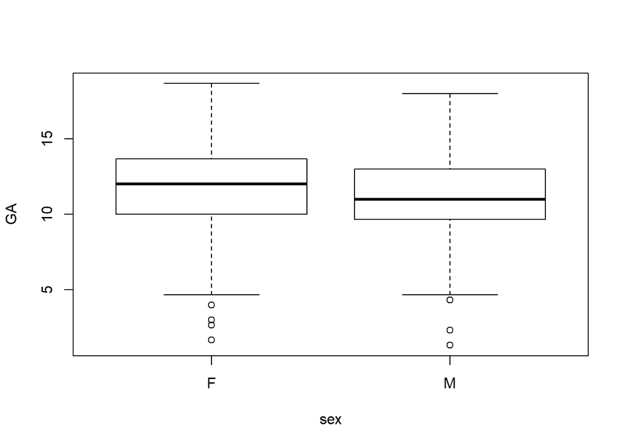

```r
boxplot(GA ~ sex, data=stData)
```

```r
#This boxplot shows that first and third quantiles for male and female students are somewhat similar, and female students have a better 50% quantile. I will do a t-test to better compare males' and females' average grades.
```

```r
t.test(GA ~ sex, data=stData)
```

```
##
##  Welch Two Sample t-test
##
## data:  GA by sex
## t = 3.0409, df = 576.48, p-value = 0.002466
## alternative hypothesis: true difference in means is not equal to 0
## 95 percent confidence interval:
##  0.2412258 1.1211880
## sample estimates:
## mean in group F mean in group M
##        11.90426        11.22306
```

```r
ttestBF(formula=GA ~ sex, data=stData, posterior=FALSE)
```

```
## Bayes factor analysis
## --------------
## [1] Alt., r=0.707 : 7.723067 ±0%
##
## Against denominator:
##   Null, mu1-mu2 = 0
## ---
## Bayes factor type: BFindepSample, JZS
```

```r
summary(ttestBF(formula=GA ~ sex, data=stData, posterior=TRUE, iterations=10000))
```

```
##
## Iterations = 1:10000
## Thinning interval = 1
## Number of chains = 1
## Sample size per chain = 10000
##
## 1. Empirical mean and standard deviation for each variable,
##    plus standard error of the mean:
##
##                 Mean       SD  Naive SE Time-series SE
## mu           11.5641  0.11246 0.0011246      0.0011283
## beta (F - M)  0.6654  0.22321 0.0022321      0.0022921
## sig2          7.9474  0.43850 0.0043850      0.0045174
## delta         0.2363  0.07953 0.0007953      0.0008157
## g             2.5176 39.43080 0.3943080      0.3943080
##
## 2. Quantiles for each variable:
##
##                  2.5%     25%     50%     75%   97.5%
## mu           11.34689 11.4882 11.5643 11.6393 11.7842
## beta (F - M)  0.21805  0.5172  0.6664  0.8183  1.0928
## sig2          7.12589  7.6488  7.9344  8.2321  8.8559
## delta         0.07659  0.1835  0.2365  0.2904  0.3876
## g             0.07492  0.1994  0.3940  0.9659 10.6619
```

```r
#The p-value is 0.002, which is smaller than the alpha value, so the result is statistically significant. The odds ratio is not very strong, but 7.7:1 is not to weak either. The CI does not overlap with zero, so there is a mean difference between females’ average grades and males’ average grades. F-M’s CI is bigger than zero, which tells us average female students tend to do a little better in terms of academic performance comparing to average male students.
```

Multiple Regression In this section, I will be running a multiple regression analysis on my dataset with lm(), using GA(average grades) as the dependent variable and Medu, Fedu, studytime, age, and absences as the predictors.

```r
summary(lm(GA ~ Medu+Fedu+studytime+age+absences, data=stData))
```

```
##
## Call:
## lm(formula = GA ~ Medu + Fedu + studytime + age + absences, data = stData)
##
## Residuals:
##      Min       1Q   Median       3Q      Max
## -10.4985  -1.4850  -0.0728   1.6438   6.5765
##
## Coefficients:
##             Estimate Std. Error t value Pr(>|t|)
## (Intercept) 12.10024    1.50343   8.048 4.06e-15 ***
## Medu         0.42384    0.11968   3.541 0.000427 ***
## Fedu         0.25332    0.12338   2.053 0.040462 *
## studytime    0.78313    0.12568   6.231 8.38e-10 ***
## age         -0.20574    0.08630  -2.384 0.017409 *
## absences    -0.05256    0.02265  -2.320 0.020628 *
## ---
## Signif. codes:  0 '***' 0.001 '**' 0.01 '*' 0.05 '.' 0.1 ' ' 1
##
## Residual standard error: 2.622 on 643 degrees of freedom
## Multiple R-squared:  0.1501, Adjusted R-squared:  0.1435
## F-statistic: 22.71 on 5 and 643 DF,  p-value: < 2.2e-16
```

```r
#The results show us all the p-values are smaller than the alpha value, which means the coefficients are statistically significant, and it looks like study time is the strongest predictor of students’ average grades. Interestingly, for mother’s education level makes a bigger impact on boosting students’ academic performance than the father’s education level does. Age and absences are negatively correlated to student average grades, and absences factor has the weakest correlation with students’ average grades amongst all the predictors.
#Then, I will be conducting a bayes factor analysis on the model.
summary(lmBF(GA ~ Medu+Fedu+studytime+age+absences, data=stData, posterior=FALSE))
```

```
## Bayes factor analysis
## --------------
## [1] Medu + Fedu + studytime + age + absences : 5.889921e+17 ±0%
##
## Against denominator:
##   Intercept only
## ---
## Bayes factor type: BFlinearModel, JZS
```

```r
#The result shows that the odd ratio is overwhelmingly big, so odds are in favor of the alternative hypothesis.
#Now, I run lmBF() with posterior=TRUE and iterations=10000 to sample from the posterior distribution.
summary(lmBF(GA ~ Medu+Fedu+studytime+age+absences, data=stData, posterior=TRUE, iterations=10000))
```

```
##
## Iterations = 1:10000
## Thinning interval = 1
## Number of chains = 1
## Sample size per chain = 10000
##
## 1. Empirical mean and standard deviation for each variable,
##    plus standard error of the mean:
##
##               Mean      SD  Naive SE Time-series SE
## mu        11.62572 0.10318 0.0010318      0.0010318
## Medu       0.41300 0.11740 0.0011740      0.0011921
## Fedu       0.24493 0.12133 0.0012133      0.0012348
## studytime  0.75811 0.12245 0.0012245      0.0012245
## age       -0.19929 0.08574 0.0008574      0.0008574
## absences  -0.05126 0.02265 0.0002265      0.0002265
## sig2       6.88490 0.38543 0.0038543      0.0038543
## g          0.07422 0.07847 0.0007847      0.0007847
##
## 2. Quantiles for each variable:
##
##                2.5%      25%      50%      75%     97.5%
## mu        11.424141 11.55667 11.62439 11.69558 11.828372
## Medu       0.181678  0.33373  0.41366  0.49159  0.640299
## Fedu       0.007144  0.16220  0.24482  0.32694  0.482422
## studytime  0.519148  0.67565  0.75731  0.84118  0.999906
## age       -0.363907 -0.25750 -0.19993 -0.14142 -0.030221
## absences  -0.095559 -0.06639 -0.05116 -0.03603 -0.006995
## sig2       6.170833  6.62253  6.86958  7.13323  7.679816
## g          0.019542  0.03740  0.05528  0.08562  0.242076
```

```r
#In section 1, the mean values are similar to the first lm() result. In section 2, none of the bounds are overlapping with 0, so all these predictors should be significant predictors for students’ average grades.
```

Conclusion: To answer my questions, I focused on analyzing how different factors related to students’ grades. After finishing up the analysis, the t-tests help me find that the students in the two schools perform differently. Students in Gabriel Pereira’s average grade is higher than that of Mousinho da Silveira. Also, female students’ average grade is slightly higher than that of male students. The multiple linear regression model tells me that parents’ education level, study time, age, and absences are all significant predictors. What surprises me is that older students tend to do worse in terms of academic performance. Moreover, mothers having high education level seems to positively impact students’ grades more if we compare the same thing with fathers. Last, study time is the strongest positive predictor to predict students’ grades, and I am not surprised by this result because I believe hard-working people deserve better results.